# NYL Adobe Analytics Audit

## Summary

Below is a summary of what we found when checking the **nylgmadlaunchprod** report suite looking at data from **2023-10-01 to 2023-12-31**.

**Note**: The raw data for everything that follows is available in [this Google Sheet](https://docs.google.com/spreadsheets/d/1k1KzFCOoijTMOy3hNNMQpV0RvCbBgfk6w4DeFsOgUSE).

|  | eVars | listvars | events | props |
| --- | --- | --- | --- | --- |
| Total Enabled | 51 | 2 | 69 | 14 |
| % with Data | 94.1% | 50.0% | 84.1% | 100.0% |
| # of Variables with NO Data | 3 | 1 | 11 | 0 |
| # of Variables with MINIMAL Data | 1 | 0 | 15 | 0 |
| % with Descriptions Present | 66.7% | 0.0% | 50.7% | 100.0% |
| # of Variables w/ Classifications | 2 | 0 | - | 0 |
| # of Classifications | 4 | 0 | - | 0 |
| % of Classifications w/ Data | 100.0% | - | - | - |
| # with Possible Launch Rule Config Issue | 0 | 0 | - | 0 |

When it comes to **traffic sources**:

- There were **1,509 unique values** for the campaign variable (tracking code).
- The campaign variable (tracking code) has **5 classifications configured**.
- Of those, **5 of the classifications are being populated with values**.

Of the **8 marketing channels** that recorded visits:

- **2 channels** each account for **less than 1% of total visits** to the site.
- **Internal** appears as a marketing channel, but it is **less than 1% of total traffic**, so this is of low concern.

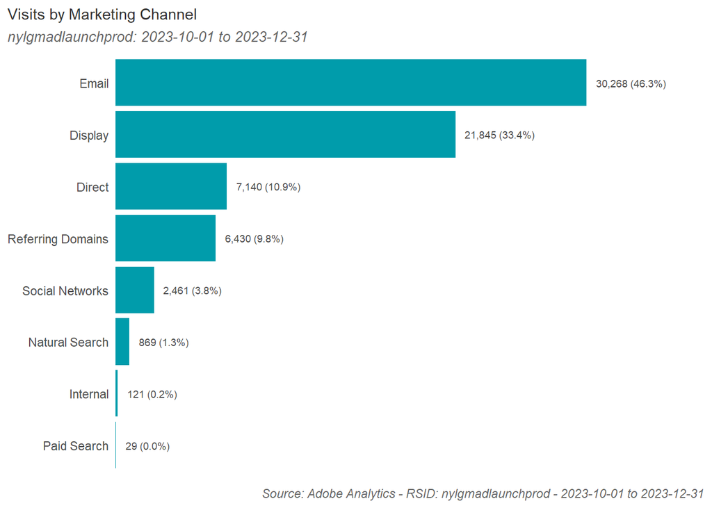

## eVars

### eVars with No Data

The following eVars have **no data** for the report period:

| eVar | Name | Description |
| --- | --- | --- |
| evar35 | Time Parting (v35) | TIme parting, gives a little broken down view of the time stamp |
| evar36 | Modal Closed Type (e36) | - |
| evar61 | Quote Button Choose Plan(v61) | - |

### eVars with Minimal Data

The following eVars have **minimal data**, defined as having **fewer than 100 total instances** of the eVar in the assessed timeframe:

| eVar | Name | Description | Total Instances |
| --- | --- | --- | --- |
| evar68 | API w equals(v68) | - | 16 |

### eVar Classifications with Data

The following eVar classifications have data. The top three values (by instances) and the number of instances of each in the timeframe are shown below:

| Classification Name | Top Value | 2nd Value | 3rd Value |
| --- | --- | --- | --- |
| Page Identifier (evar1) | eligibility (595,506) | contact (533,757) | coverageselection (190,620) |
| Number of Products Applied For (evar67) | 1 (3,950) | 2 (1,215) | 3 (302) |
| Products Applied For (evar67) | Primary Group Term Life Insurance (1,139) | Primary Group Accidental Death and Dismemberment\|Primary Disability Income Insurance (209) | Primary Guaranteed Issue Group Term Life (208) |
| Receipt ID (evar67) | 1123456789 (5) | 100000454632 (1) | 100000462399 (1) |

## listvars

### listvars with No Data

The following listvars have **no data** for the report period:

| listvar | Name | Description |
| --- | --- | --- |
| listvariable3 | Input Error Message (lv3) | - |

## Events

### Events with No Data

The following events have **no data** for the report period:

| event | Name | Description | Type |
| --- | --- | --- | --- |
| event41 | Signing Your Application page (e41) | - | int |
| event63 | API w equals(e63) | URLcontains query param ‘w=’ | int |
| event67 | Lexus Nexus Initiate(e67) | Lexus Nexus Initiate | int |
| event69 | Lexus Nexus Success(e69) | Lexus Nexus Authentication Success | int |
| event70 | Lexus Nexus Failure(e70) | Lexus Nexus Authentication Failure | int |
| event71 | Lexus Nexus Coverage(e71) | Lexus Nexus Coverage | int |
| event80 | Advisor Saved App Continued (e80) | When a user continues an advisor-initiated application | int |
| event86 | CIR Health Questions - Spouse (e86) | Counts how many times a user saw the CIR Health Questions - Spouse page | int |
| event89 | Advisor Signature Modal ‘Yes’ Click (e89) | - | int |
| event90 | Advisor Signature Modal ‘No’ Click (e90) | - | int |
| event91 | Advisor Confirmation Blank Page (e91) | - | int |

### Events with Minimal Data

The following events have **minimal data** for the report period, defined as having a total value below 100 in the assessed timeframe:

| event | Name | Description | Type | Event Total |
| --- | --- | --- | --- | --- |
| event17 | Products(e17) | - | int | 98 |
| event26 | form cancel(e26) | - | int | 44 |
| event43 | Payment Page (e43) | - | int | 40 |
| event50 | Qualtrics(e50) | User Clicked Qualtric Feedback button | int | 3 |
| event53 | health history spouse(e53) | - | int | 15 |
| event56 | Health Questions(e56) | Health Questions Page | int | 73 |
| event62 | Marketing Button(e62) | User Clicked Marketing Button | int | 45 |
| event64 | Surfly(e64) | User Clicked Co-Browsing Help Button | int | 74 |
| event68 | Lexus Nexus User Authenticate(e68) | Lexus Nexus User Authenticate | int | 5 |
| event79 | Advisor Confirmation (e79) | - | int | 15 |
| event82 | Disability Needs Calc Button Impression (e82) | The logic was turned off on 12/5/23. Will revisit adding it back later. Counts how many times the Disability Needs calculator button was displayed | int | 24 |
| event83 | Needs Calc Button Click (e83) | Counts how many times the button to open the Needs Calculator was clicked | int | 11 |
| event84 | Calculate Benefit Amount Click (e84) | Counts how many times the Calculate Benefit Amount button in the Needs Calculator modal was clicked | int | 13 |
| event85 | CIR Health Questions - Self (e85) | Counts how many times a user saw the CIR Health Questions - Self page | int | 22 |
| event87 | Financial Information(e87) | Captures the first click within the Financial Information section on the Contacts Page. | int | 24 |

### Event Trends

Below is a daily trend plot for each event that has any data:

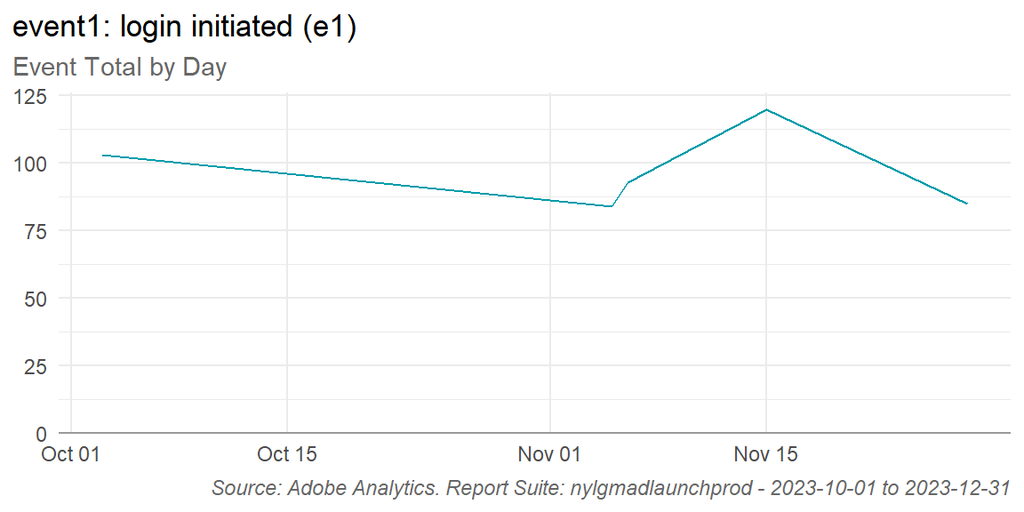

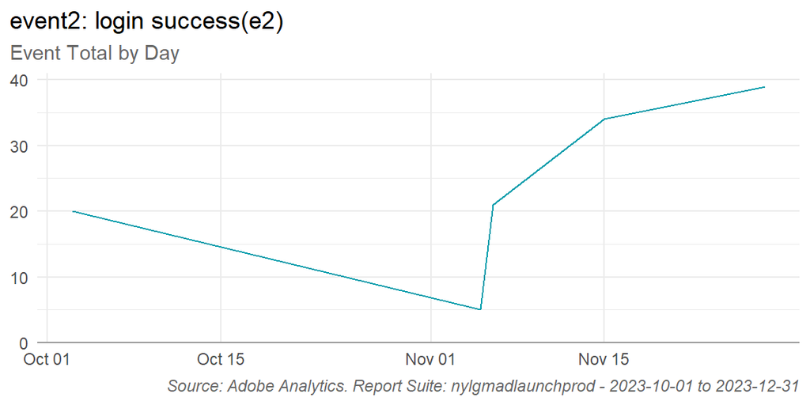

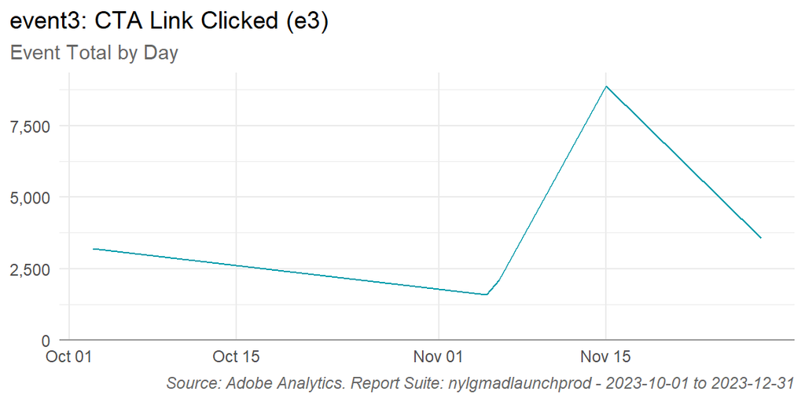

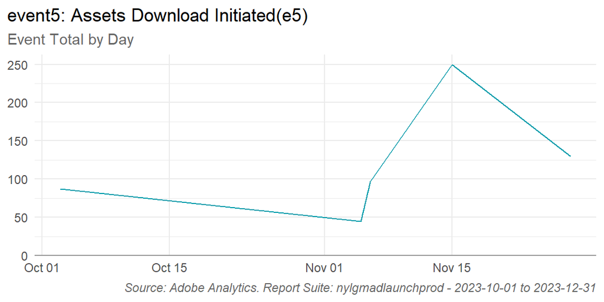

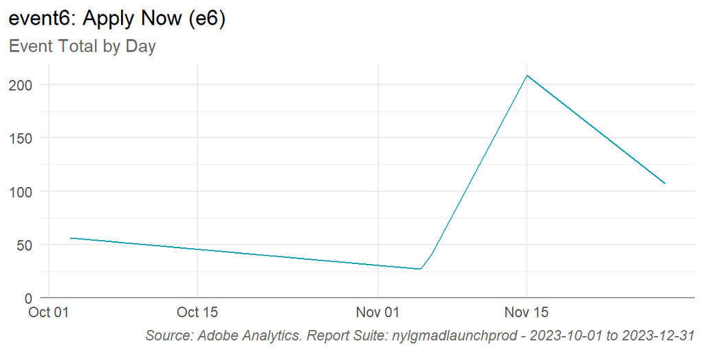

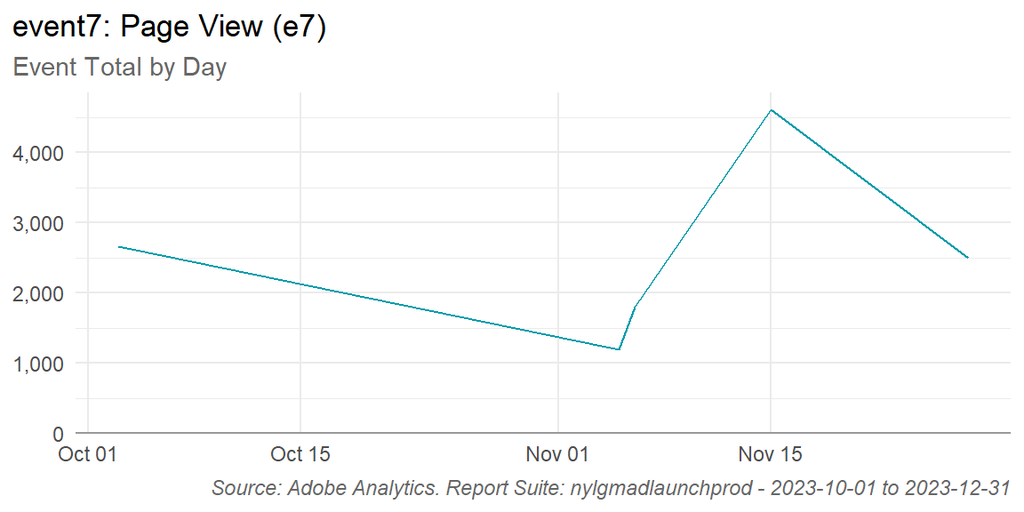

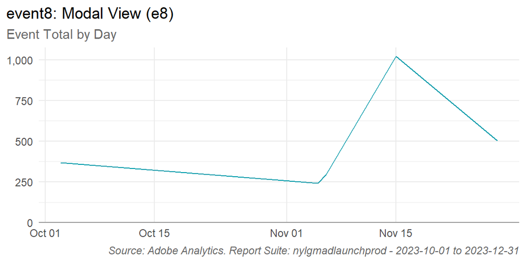

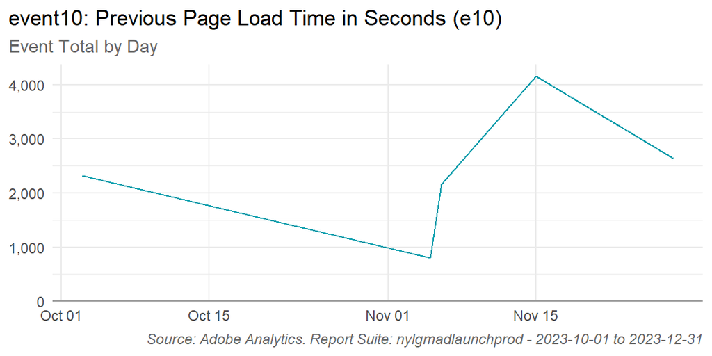

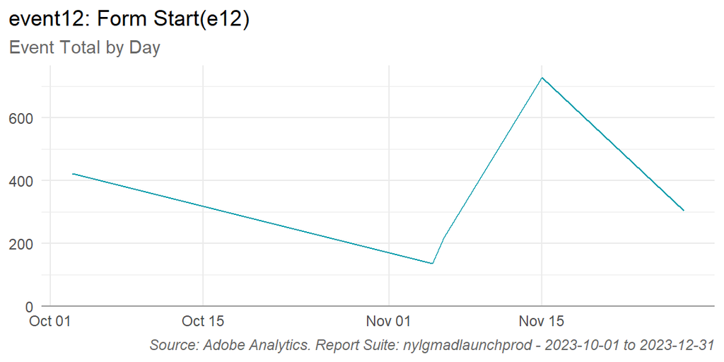

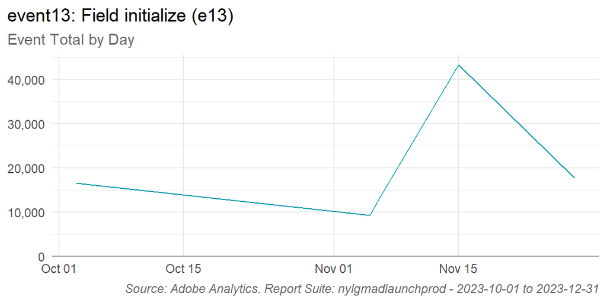

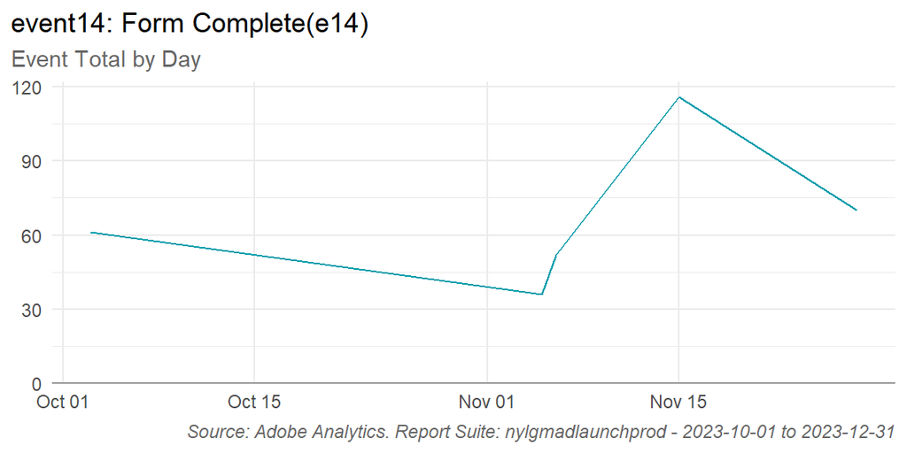

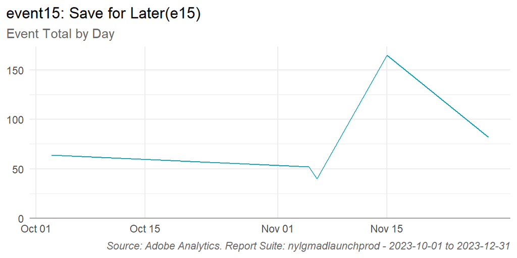

[46 more figures not shown]

## Traffic Sources

The following are some highlights.

### Marketing Channels

Total visits by marketing channel in the assessed period are shown below:

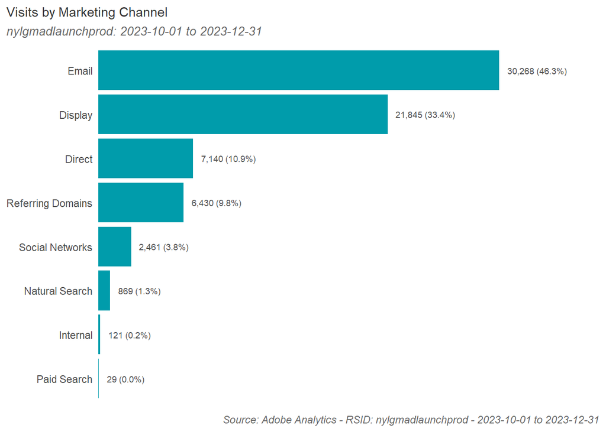

Looking at the marketing channel details, the number of unique “Marketing Channel Detail” values for each marketing channel, as well as the top 3 of those values (by visits) are as follows:

| Marketing Channel | % of Visits | # of Channel Details | Top Value | 2nd Value | 3rd Value |
| --- | --- | --- | --- | --- | --- |
| Email | 46.3% | 789 | 089028010505 (6,868) | None (1,603) | 2200002 (1,410) |
| Display | 33.4% | 818 | pass (2,087) | A0A000 (1,402) | AVMALIFE-NYL-OL (1,118) |
| Direct | 10.9% | 105 | None (2,332) | gmad:application:csea:eligibility (960) | gmad:application:isitrust:genericquote (826) |
| Referring Domains | 9.8% | 208 | www.waepa.org (3,262) | www.omainsurance.com (431) | www.aafpins.com (374) |
| Social Networks | 3.8% | 6 | m.facebook.com (1,811) | l.facebook.com (259) | www.linkedin.com (253) |
| Natural Search | 1.3% | 4 | n:Google:::empty:: (656) | n:Microsoft Bing:::empty:: (183) | n:Yahoo!:::empty:: (27) |
| Internal | 0.2% | 19 | None (42) | gmad:application:waepa:genericquote (21) | gmad:application:nso:genericquote (16) |
| Paid Search | 0.0% | 1 | p:Google:::empty:: (29) |  |  |

## Audit Duration

This audit took **9.7 mins** to complete.